# Exploring the Relationship between Trifectas in State Governments and Spending on Education using Multilevel Modeling

Peter Silverstein and Sam Gartenstein

2025-06-04

We are interested in the relationship between state-level education spending and the control of state-level executive and legislative branches. More specifically, we are interested in “trifectas,” which refer to situations where a single party controls the Governorship, Senate, and House of Representatives within a state.[^1] How does education spending change when this happens?

Trifectas are tracked by the Lucy Burns Institute through ballotpedia.org, and have been the subject of academic research in the past. One study found that state-level obesity-related policies differ between states with Democratic trifecta control and states with Republican trifecta control, and that these both differed from policies in states with divided government.[^2] Another found that tax revenues tend to increase under Democratic trifectas and slightly decline under Republican ones.[^3]

Our goal with this project is to better understand how partisan trifectas are associated with changes in education spending. The use of multilevel models in this case are twofold. First, we can explicitly adjust for year-level effects, which is important given that trifectas are becoming more frequent over time and that education spending is also increasing over time. Second, we can adjust for state-level effects. That is, by including state as a varying-intercept term, we get closer to examining the effect of a trifecta over and above the state-level effects that arise from the general partisanship of a state.

## Description of Data Sources

This analysis relies on several different data sources. The outcome variable, education spending per pupil, comes from the State-by-State Spending on Kids dataset available from Urban.org.[^4] The outcome variable is adjusted to reflect 2016 dollars.

Data for the control of state legislatures (Senate and House) and governorship was accessed via the Lucy Burns Institute through ballotpedia.org.[^5] The dataset denotes control of each governing entity with a -1 for Democrats, 0 for split control/independent, and 1 for Republicans. Data preprocessing was done to identify years/state combinations in which (a) either trifecta existed and (b) which party the trifecta was for.

## Summary Statistics

Our final dataset consists of 833 observations, covering 49 states from 1997 to 2013. Nebraska is omitted from this analysis due to missing data on state legislature party affiliation. The first graph shows the percentage of unified party control of state government by year across the country. Over the sample period, the proportion of states with unified Republican control increased relative to unified Democratic control, with a noticeable increase around 2010. The second graph shows the relationship between the number proportion of unified Republican control through the entire period. Although there is considerable variability in spending among states with no Republican control, states with higher proportions of full Republican control tend to have lower average per-pupil spending, with smaller variability. This suggests a potential negative correlation between unified Republican control and education spending levels.

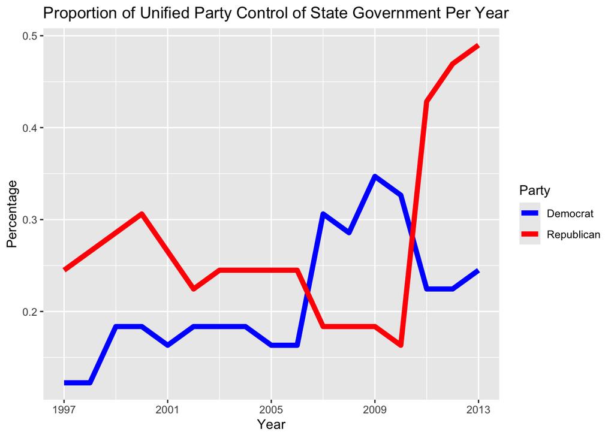

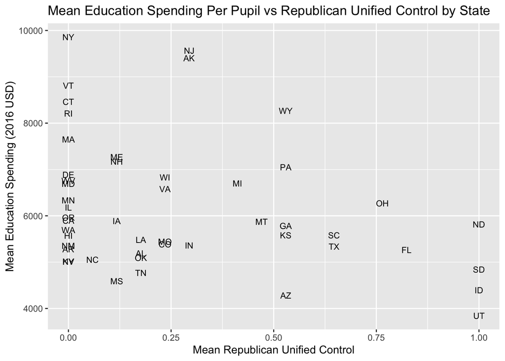

## Results

### Model 1: Linear Regression of Education Spending on Unified Control

```
## stan_glm
##  family:       gaussian [identity]
##  formula:      log(educ_spending) ~ unified_control
##  observations: 833
##  predictors:   2
## ------
##                 Median MAD_SD
## (Intercept)      8.724  0.012
## unified_control -0.048  0.018
##
## Auxiliary parameter(s):
##       Median MAD_SD
## sigma 0.246  0.006
##
## ------
## * For help interpreting the printed output see ?print.stanreg
## * For info on the priors used see ?prior_summary.stanreg
```

### Model 2: Hierarchical Linear Regression of Education Spending on Unified Control

```
## stan_glmer
##  family:       gaussian [identity]
##  formula:      log(educ_spending) ~ unified_control + under19_pop_prct + white_pop_prct +
##     income_adj + unemployment_rate + (1 | State) + (1 | Year)
##  observations: 833
## ------
##                   Median MAD_SD
## (Intercept)        9.841  0.212
## unified_control   -0.012  0.005
## under19_pop_prct  -4.620  0.474
## white_pop_prct    -0.134  0.178
## income_adj         0.000  0.000
## unemployment_rate -0.002  0.002
##
## Auxiliary parameter(s):
##       Median MAD_SD
## sigma 0.055  0.001
##
## Error terms:
##  Groups   Name        Std.Dev.
##  State    (Intercept) 0.17361
##  Year     (Intercept) 0.08719
##  Residual             0.05466
## Num. levels: State 49, Year 17
##
## ------
## * For help interpreting the printed output see ?print.stanreg
## * For info on the priors used see ?prior_summary.stanreg
```

### Model 3: Hierarchical Linear Regression of Education Spending on Partisan Unified Control

```
## stan_glmer
##  family:       gaussian [identity]
##  formula:      log(educ_spending) ~ r_unified_control + d_unified_control +
##     under19_pop_prct + white_pop_prct + income_adj + unemployment_rate +
##     (1 | State) + (1 | Year)
##  observations: 833
## ------
##                   Median MAD_SD
## (Intercept)        9.868  0.213
## r_unified_control -0.008  0.006
## d_unified_control -0.014  0.006
## under19_pop_prct  -4.686  0.479
## white_pop_prct    -0.146  0.175
## income_adj         0.000  0.000
## unemployment_rate -0.002  0.003
##
## Auxiliary parameter(s):
##       Median MAD_SD
## sigma 0.055  0.001
##
## Error terms:
##  Groups   Name        Std.Dev.
##  State    (Intercept) 0.17358
##  Year     (Intercept) 0.08706
##  Residual             0.05465
## Num. levels: State 49, Year 17
##
## ------
## * For help interpreting the printed output see ?print.stanreg
## * For info on the priors used see ?prior_summary.stanreg
```

## Limitations and Discussion

Though the coefficient estimates for our models are relatively stable and produce relatively small standard errors, there are several limitations to this project that deserve discussion. First, there are always some data quality issues. Nebraska has an idiosyncratic state government–its legislative branch is unicameral and does not distinguish party lines, meaning it returns missing values for our data and is thus excluded.[^9] It is difficult to say whether an effort should be made to include Nebraska in the study. On the one hand, it is a largely Republican state, so it would likely make the model on education spending somewhat better and more accurate. On the other hand, the whole point of the study is to understand trifectas, a phenomenon that does not necessarily occur in Nebraska given its legislative system. At this point, we chose to omit Nebraska for simplicity, and our models should be interpreted with this in mind.

Another limitation is in the formulation of the unified control variable and the inclusion of state-level effects. Our initial models included binary variables for partisan control in each of the state House, Senate, and Governorship, but these omitted the extra effect of the trifecta and their effects seemed to be eaten up by the state-level varying intercept term. That said, it may be that the correct approach is to include the binary terms by legislative body, the trifecta indicator, and the state-level effects.

Finally, the results from this model are not causal. Though it may be possible to conceptualize trifecta control as a sort of treatment, confounders abound. Adjusting for state-level and year-level effects may be a start, but we can think of a host of situations in which a state might be more likely to get a trifecta that may also impact education spending. For example, it might be useful to include some economic performance indicators, or other variables that tend to predict incumbent/controlling party success in state-level elections. Further, though we account for the proportion of the population under 19, it may be that education spending fluctuates in line with the retiree population of a state. Lastly, we do not account for federal-level policy decisions that might impact state-level spending. This may be the biggest weakness of the models. We think that adjusting for year is a start, given that year-level effects might vary with federal policy changes, but it would be better to explicitly adjust for it in some way.

[GitHub Repository for this Project](https://github.com/Peter-Silverstein/educ-spending-proj)

[^1]: https://ballotpedia.org/State_government_trifectas
[^2]: https://www.sciencedirect.com/science/article/pii/S0091743517303171
[^3]: https://www.multistate.us/insider/2022/11/28/how-political-trifectas-can-affect-your-tax-bill
[^4]: https://datacatalog.urban.org/dataset/state-state-spending-kids-dataset
[^5]: https://ballotpedia.org/Ballotpedia:Who_Runs_the_States,_Partisanship_Results,_Partisan_Control_of_State_Legislatures
[^6]: https://wonder.cdc.gov/bridged-race-v2019.html
[^7]: https://www.census.gov/data/tables/time-series/demo/income-poverty/historical-income-households.html
[^8]: https://www.bls.gov/lau/rdscnp16.htm
[^9]: https://nebraskalegislature.gov/about/about.php